# App-3) California Crash Data

Stat 133, Fall 2024

Author

Gaston Sanchez

**Content Notice**

I acknowledge that each of you comes to UC Berkeley with your own unique life experiences. This contributes to the way you perceive various types of information.

The content of this assignment includes crash data in California. This content was obtained through UC Berkeley’s *Safe Transportation Research and Education Center* (SafeTREC).

The decision to include such material is not taken lightly, and I’m doing so in order to achieve the learning goals for this course: to apply the analytical and coding skills utilizing real-world data sets.

Me and the teaching staff want to do our best to make any conversations we have about this content in class feel safe for you. If you have thoughts to share with us about this, please do send us a note through Ed or email.

# About

The purpose of this assignment is to create a **shiny app** to visualize California Crash Data between 2014 and 2023. Use this assignment as an opportunity to put in practice everything that you’ve learned so far in class, as well as other analytical skills and concepts that you’ve learned in other classes that can be applicable to STAT 133.

All files related to this assignment are available in bCourses (see *Files/hws/app3*)

https://bcourses.berkeley.edu/courses/1536526/files/folder/hws/app3

- `app3-instructions.html`: instructions
- `app3-template-3tabs.R`: template containing 3 tabs
- `app3-template-2tabs.R`: template containing 2 tabs
- `crashes_california_2014_2023.csv`: CSV file
- `crash-data-dictionary.pdf`: data documentation
- `crashes-leaflet-tutorial.html`: companion tutorial

# 1 Data: California Crash Data (2014-2023)

The source of the data for this assignment is the **Statewide Integrated Traffic Records System** (SWITRS) which consists of data collected and maintained by the *California Highway Patrol* (CHP).

Special thanks go to Amalia Stahl—from the *Safe Transportation Research and Education Center* (SafeTREC) at UC Berkeley—who provided the CSV file for this assignment.

### CSV File

You can find the data, **in CSV** format, in the file `crashes_california_2014_2023.csv` located in bCourses (see `Files/hws/app3`):

https://bcourses.berkeley.edu/courses/1536526/files/folder/hws/app3

**In case of trouble …**

If you have issues having access to the data in bCourses, you can also download a compressed (*zipped*) file from the URL:

https://tinyurl.com/45wa8mpj

### Data Dictionary

https://bcourses.berkeley.edu/courses/1536526/files/folder/hws/app3?preview=90220285

# 2 Shiny App

The goal of this assignment is to create a shiny app that allows the user to visualize and explore California Crash Data, answering questions related to the when, where, what, why, and how crashes occur. In other words, **the analyses in your app should answer a combination** of the following open-ended questions (relevant variables listed in bullet points):

**WHEN** do crashes (all or of a certain kind) occur?

- `ACCIDENT_YEAR` (year of accident)
- `COLLISION_DATE` (`yyyy-mm-dd`); recall that `"lubridate"` functions `month()`, `week()`, `day()`, etc can be your friends.
- `DAY_OF_WEEK` (day of week)
- `HOUR` (hour of day)

**HOW** do crashes occur, and how severe can they be? By this we refer to the type of collision, and the crash severity

- `TYPE_OF_COLLISION`
- `COLLISION_SEVERITY`

**WHY** do crashes occur? By “why” we refer to the primary cause of the accident.

- `PCF_VIOL_CATEGORY`

**WHERE** do (certain kind of) crashes occur? To answer this question you’ll have to use a leaflet map.

- `POINT_X` (longitude)
- `POINT_Y` (latitude)
- `PO_NAME` (post office name, used as a proxy for city)
- `COUNTY`
- `CITY`

**WHAT** kind of patterns, or trends, or associations can be determined from the analyzed data?

**Clarification on the data variables …**

The relevant variables listed above are not meant to be an exhaustive list of all the variables present in the data. Also, your analysis does not have to be limited to the listed variables. You are encourage to use other variables that can definitely enrich your exploratory analysis.

## 2.1 Template Files

We are providing two template R script files available in bCourses (see *Files/hws/app3*):

https://bcourses.berkeley.edu/courses/1536526/files/folder/hws/app3

- `app3-template-2tabs.R`: this template contains 2 tabs
- `app3-template-3tabs.R`: this template contains 3 tabs

You only need to choose one template, but your app must contain at least 2 tabs.

## 2.2 Layout

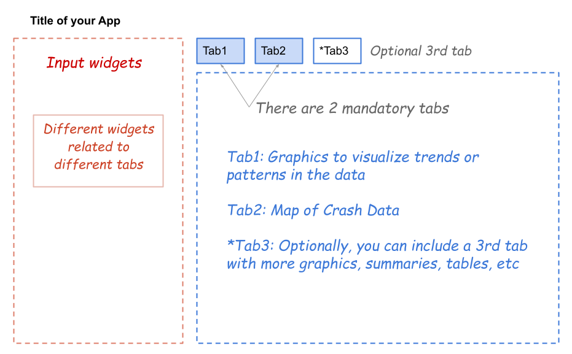

Figure 2: Shiny App-3 Layout

As you can tell from the above diagram, the provided layout in the template file uses a sidebar, but also outputs divided in two (or optionally three) tabs. These tabs correspond to:

1. Tab-1: Graphics to visualize trends or patterns in the data.
2. Tab-2: Interactive (leaflet) map of crash data.
3. Tab-3: Optional tab to include more graphics, summaries, tables, etc.

## 2.3 Specs

From the diagram in figure 2, note that there are five distinctive sections in the layout—see template files:

- **Title**: Main title for your app (give it a meaningful name).
- **Input widgets**: The template comes with a sidebar panel that contains the input widgets. Keep in mind that the widgets are divided into two or three sections, depending on the number of utilized tabs.
- **Tab-1: graphics**: The first tab should be used to display three or more graphics to visualize interesting trends or patterns in the data, answering a combination of (open-ended) questions related to the when, where, what, why, and how crashes occur. Because there is a large number of ways in which variables could be combined (e.g. crashes by `COUNTY` per `ACCIDENT_YEAR`, `COLLISION_SEVERITY` per `DAY_OF_WEEK`, etc), the user should be allowed to see at least one of the graphics divided into **facets**.
- **Tab-2: map**: The second tab has to do with the leaflet map to display the location of crashes. The user should be allowed to indicate **at least** a specific year (`ACCIDENT_YEAR`), one or more cities (via the post office `PO_NAME`), and one or more violation categories (`PCF_VIOL_CATEGORY`). The user should also have the opportunity to see color coded crashes based on either `TYPE_OF_COLLISION` or `COLLISION_SEVERITY`. Likewise, include a `label` so that when you hover over a certain crash the user will see important information such as the date of the crash, and/or the type of crash, and/or the cause of the crash.
- **Tab-3: more**: If you feel that two tabs are not enough for the kind of analyses you are performing, then include a third tab! We’ll be more than happy to see that you can’t get enough from shiny web apps. Not to mention that Prof. Sanchez will very likely be tremendously proud of you!

# 3 Submission

Like in app1, your submission should include the following:

- 📄 R File
- 🔗 Link to published app
- 🎬 Link to video

## 3.1 📄 R File

You will have to submit—to bCourses—the `app.R` file (do NOT confuse with a `qmd` file) containing the code of your app.

## 3.2 🔗 Link to published app

You will also have to submit the link to your published app in [shinyapps.io](https://www.shinyapps.io/) (the free version). Share the link with us in the comments section of the submission in bCourses.

## 3.3 🎬 Link to Video

In addition to the `app.R` file, you will also have to record a video—maximum length of 4:00 minutes—with both **screen and face** capture, in which you show us your published shiny app, how to use it, and a description of the produced visualizations. Share the **public link** with us in the comments section of the submission in bCourses.

Regardless of where you decide to host the file of your video, you must share the **public link** (don’t make it private) in bCourses: use the “comments section” of the submission to add this link as a comment. To be clear: do NOT upload the video to bCourses, just its link.

Make sure that the video does not exceed 4 minutes, that its resolution is okay, without too much background noise, avoid very low volume or inaudible audio, and also ensure that your image is stable (don’t make us watch a shaky video).

## Rubric

Roughly speaking, the code of the app (app.R) is worth about 70%, the video is worth about 20%, and the published app (shinyapps.io) is about 10%.

**0 pts:**

- Didn’t attempt or very very wrong/poor.

**1-2 pts:**

- Got started and made initial progress, but went off in the wrong direction or with no clear direction. And/or mostly incomplete.

**3-4 pts:**

- Got started and made some progress, but submission elements are highly incomplete or have major/fatal issues.

**5 pts:**

- Somewhat in the right direction and got half-way there.
- All elements (app.R, shinyapps.io, video) are submitted; app has major/fatal issues.
- shinyapps.io AND video missing or not working (app.R submitted); code in app is mostly complete but has major issues.

**6 pts:**

- shinyapps.io AND video missing (app.R submitted); app has some minor thing missing or wrong.

**7 pts:**

- shinyapps.io AND video missing or don’t work (app.R submitted); app is complete and works okay.
- Video missing or not working (app.R and shinyapps.io are submitted); app has minor issues.
- All elements (app.R, shinyapps.io, video) are submitted; app has major issues.

**8 pts:**

- Video missing (app.R and shinyapps.io are submitted); app is complete and works okay.
- All elements (app.R, shinyapps.io, video) are submitted; app/video has various minor issues.

**9 pts:**

- shinyapps.io missing or does not work (app.R and video are submitted); app is complete and works okay.
- All elements (app.R, shinyapps.io, video) are submitted; app/video mostly right but a minor thing missing or wrong.

**10 pts:**

- All elements (app.R, shinyapps.io, video) are submitted; 100% complete, meets all requirements, everything works as expected, video is well recorded and explanations/descriptions are good and sound.